# cyDefine - User Guide

Clara Drachmann & Søren H. Dam

Last updated: 2026.03.23

This vignette will walk you through the full pipeline of `cyDefine`. The adapt reference step is optional but relevant when you want to adapt a reference of a larger marker panel (e.g., when using the PBMC reference offered with `cyDefine`) to a smaller query panel.

The vignette will cover both how you can load in your own reference and how you can use the built-in PBMC reference.

The vignette will cover data preparation, mapping of marker naming conventions, reference adaptation, batch correction via `cyCombine`, cell type annotation, identification of unassigned cells, and visualizations.

## Installation

`cyDefine` builds on top of `cyCombine`. Both packages can be installed from GitHub:

```r
# To ensure Rstudio looks up BioConductor packages run:
setRepositories(ind = 1:2)
# Then install package with
remotes::install_github("biosurf/cyCombine")
remotes::install_github("biosurf/cyDefine")
```

## Load required libraries

```r
library(cyCombine)
library(cyDefine)
```

## Data preparation

The modules of `cyDefine` work on `data.frames` with cells by rows and markers (along with potential metadata) by columns.

Importantly, the reference needs a `celltype` column, and both reference and query need a column named `batch` if batch effects are to be corrected for within the reference and/or query. Otherwise, only technical variations between the reference and query will be corrected.

The following sections demonstrate how either the inbuilt or a custom reference is loaded, and how a query is loaded from FCS files. A `Seurat` or `SingleCellExperiment` object can easily be converted to a `data.frame` as well, just remember to include the relevant metadata as a column.

### Universal PBMC reference

`cyDefine` comes with a universal PBMC reference. See `?pbmc_reference` for more details. In short, it can be loaded and optionally stored with the following function:

```r
reference <- get_reference(
  "pbmc",
  store = FALSE
)
```

In case more references are included, they can be listed with `cyDefine:::get_all_references()`.

### Prepare reference and query from FCS files

The first step is to convert a directory of FCS files into a `data.frame` that `cyDefine` can process. In that process, we utilize the convenience functions from `cyCombine` to add optional metadata to the `data.frame`, such as sample IDs, potential conditions, batch information, as well as other features. For a custom reference, a *“celltype”* column is also required.

#### Marker panel

Information on the marker panel can either be given as a character vector of marker names or as a panel file, i.e., a CSV/Excel file with columns that specify the FCS channel and antigen. See `?prepare_data` for panel arguments.

#### Metadata

The remaining information can either be extracted directly from the file names, if present within them, or it can be given in a metadata CSV/Excel file with columns `filename`, and e.g. `batch`, `condition`, etc. See `?prepare_data` for metadata arguments.

If you want to extract the metadata from the FCS file names, use the `extract_filename_regex` and `extract_filename_into` arguments. More information can be found in the function documentation `?prepare_data`, but here is an example:

```r
# Markers of interest
markers <- c('CD16', 'CD26', 'CD8a', 'CD33', 'CD161', 'CCR10', 'CCR7', 'CCR9',
             'CD3', 'ICOS', 'CD45RA', 'CD27', 'CXCR3', 'NKG2A', 'CD14', 'CD127',
             'CD57', 'HLADR', 'CD62L', 'CD19', 'IgG', 'CD4', 'IgD', 'IgA',
             'CD86', 'CCR6', 'CD20', 'CD56', 'TCRgd', 'CD123', 'CD11c', 'CD25',
             'CXCR5', 'CD38', 'a4b7', 'PD1', 'CLA')

# Prepare reference tibble from directory of FCS files
reference <- prepare_data(
  data_dir = system.file("extdata", package = "cyDefine", mustWork = TRUE),
  pattern = "Plate3_Sample1", # Using Sample1 from Plate3 as reference
  markers = markers,
  clean_colnames = TRUE,      # Set to FALSE, if you want marker names exactly like in your panel file or FCS files.
  transform = TRUE,           # ArcSinh transformation
  cofactor = 5,               # CyTOF: 5, flow cytometry: 150, spectral: 6000
  derand = TRUE,              # Derandomization, only for CyTOF
  compensate = FALSE,         # Compensation for spectral overlap, only for flow
  extract_filename_regex = "\\d{2}Feb18_Helios2_(Plate\\d+)_(Sample\\d+)_HIMCctrl_(.+)$",
  extract_filename_into = c("batch", "sample", "celltype"))

# Prepare reference tibble from directory of FCS files
query <- prepare_data(
  data_dir = system.file("extdata", package = "cyDefine", mustWork = TRUE),
  pattern = "Plate4_Sample1", # Using Sample1 from Plate4 as query
  markers = markers,
  transform = TRUE,         # ArcSinh transformation
  cofactor = 5,             # CyTOF: 5, flow cytometry: 150, spectral: 6000
  derand = TRUE,            # Derandomization, only for CyTOF
  compensate = FALSE,       # Compensation for spectral overlap, only for flow
  extract_filename_regex = "^\\d{2}Feb18_Helios2_(Plate\\d+)_(Sample\\d+)",
  extract_filename_into = c("batch", "sample"))
```

Check that column names of reference and query include all the expected information (incl. overlapping marker names): If marker names do not match, see `?map_marker_names`.

```r
colnames(reference)
```

```
 [1] "CD16"     "CD26"     "CD8a"     "CD33"     "CD161"    "CCR10"
 [7] "CCR7"     "CCR9"     "CD3"      "ICOS"     "CD45RA"   "CD27"
[13] "CXCR3"    "NKG2A"    "CD14"     "CD127"    "CD57"     "HLADR"
[19] "CD62L"    "CD19"     "IgG"      "CD4"      "IgD"      "IgA"
[25] "CD86"     "CCR6"     "CD20"     "CD56"     "TCRgd"    "CD123"
[31] "CD11c"    "CD25"     "CXCR5"    "CD38"     "a4b7"     "PD1"
[37] "CLA"      "batch"    "sample"   "celltype" "id"
```

```r
colnames(query)
```

```
 [1] "CD16"   "CD26"   "CD8a"   "CD33"   "CD161"  "CCR10"  "CCR7"   "CCR9"
 [9] "CD3"    "ICOS"   "CD45RA" "CD27"   "CXCR3"  "NKG2A"  "CD14"   "CD127"
[17] "CD57"   "HLADR"  "CD62L"  "CD19"   "IgG"    "CD4"    "IgD"    "IgA"
[25] "CD86"   "CCR6"   "CD20"   "CD56"   "TCRgd"  "CD123"  "CD11c"  "CD25"
[33] "CXCR5"  "CD38"   "a4b7"   "PD1"    "CLA"    "batch"  "sample" "id"
```

```r
all(colnames(query) %in% colnames(reference))
```

```
[1] TRUE
```

Additionally, check that the cell types of the reference are appropriate as these will be transferred to the query:

```r
unique(reference$celltype)
```

```
 [1] "B-IgDnegCD27neg"          "B-IgDnegCD27pos"
 [3] "B-IgDposCD27neg"          "B-IgDposCD27pos"
 [5] "Basophil"                 "CD4-CM"
 [7] "CD4-Eff"                  "CD4-EM"
 [9] "CD4-Naive"                "CD4CD8dblneg"
[11] "CD4CD8dblpos"             "CD4pos_Treg"
[13] "CD56brightNK"             "CD8-CM"
[15] "CD8-Eff"                  "CD8-EM"
[17] "CD8-Naive"                "mDCs"
[19] "Monocytes-CD16negCD14neg" "Monocytes-CD16negCD14pos"
[21] "Monocytes-CD16posCD14neg" "Monocytes-CD16posCD14pos"
[23] "NK"                       "NKT"
[25] "Non-pDC-non-mDC"          "NonNK-nonDC"
[27] "pDCs"                     "Tcells_TCRgd"
```

We see that two cell types do not represent canonical populations and are better described by ‘unassigned’. We will label them accordingly:

```r
unassigned_names <- c("Non-pDC-non-mDC", "NonNK-nonDC")

# rename cell types
reference$celltype[reference$celltype %in% unassigned_names] <- "unassigned"
```

### Prepare data from CSV / data.frame

If your data is in another format than CSV, you should convert it appropriately. `prepare_data` can also convert a `flowSet` by using the *“flowset”* argument instead of *“data_dir”*. If needed `transform_asinh()` can transform a `data.frame` in cases where `prepare_data` is not needed.

## Run cyDefine with a single function

To make cell type identification with `cyDefine` as simple as possible, we offer a wrapper of the four main modules: `reference adaptation`, `batch correction`, `celltype classification`, and `identification of unassigned cells`. Thereby, if you are not interested in any intermediary information, `cyDefine` can be performed by running a single function. However, running the workflow in steps provides more control over hyperparameters and intermediate outputs.  
Details on the various steps in the workflow is presented in the next section. Functions to visualize the results are demonstrated in the last section.

```r
classified <- cyDefine(
  reference,
  query,
  markers,                          # markers/features to use
  num.threads = 1,                  # Number of threads for parallelization
  mtry = floor(length(markers)/3),  # Number of markers to use in random forest classification
  num.trees = 500,                  # Number of trees to build in classification
  use.weights = TRUE,               # Whether to weigh the celltype assignment by abundance weights
  adapt_reference = TRUE,           # Whether the reference should be adapted to the markers available in the query
  using_pbmc = FALSE,               # Whether the PBMC reference is used
  batch_correct = TRUE,             # Whether to integrate the reference and query using cyCombine (see ?cyCombine::batch_correct for more options)
  xdim = 6, ydim = 6,               # Clustering dimensions for the integration
  identify_unassigned = TRUE,       # Whether unassignable cells should be identified
  train_on_unassigned = FALSE,       # Whether unassigned cells should be identified unsupervised or using unassigned cells in the reference
  unassigned_name = "unassigned",   # Name of unassigned cells in the reference
  seed = 332,
  verbose = TRUE
  )
```

`cyDefine()` returns three objects: “query” - the classified query, “reference” - the adapted and integrated reference, and “model” - the random forest model trained on the reference and used for classification.

## Running the cyDefine workflow in steps

For more control over parameters and intermediate output, the `cyDefine` workflow can be run in steps.

### Adapt reference

The first step is to adapt the reference to the markers in the query. If these markers are identical, you can safely skip this step.

```r
mtry <- floor(length(markers)/3)
reference <- adapt_reference(
      reference = reference,
      markers = markers,
      num.threads = 4,
      mtry = mtry,
      min_f1 = .7,
      using_pbmc = FALSE,
      verbose = TRUE
      )
```

```
# ------- Population merging - Round 1 ------- #
```

```
Running classification to identify similar populations
```

```
Merging groups of similar populations
```

```
Merging:
    Monocytes-CD16posCD14neg, CD8-Eff, CD8-Naive, mDCs
    unassigned, NK
```

```
# ------- Population merging - Round 2 ------- #
```

```
Running classification to identify similar populations
```

```
Reference adapted!
```

### Batch correction via cyCombine

If your reference and query samples do not originate from the same experimental batch, technical variance, referred to as batch effects, can lead to disparate signal intensities of cells of the same phenotype, between the samples. Therefore, `cyDefine` offers batch correction via `cyCombine` [(Pedersen et al., 2022)](https://www.nature.com/articles/s41467-022-29383-5), which allows for correction of batch effects within as well as across technologies. (This step is only strictly necessary if the reference and query stem from different batches/experiments). See `?cyCombine::batch_correct` for additional parameters and [the cyCombine vignettes](https://biosurf.org/cyCombine.html) for demonstrations of use cases.

```r
corrected <- cyDefine::batch_correct(
  reference,
  query,
  markers = markers,
  covar = NULL,
  xdim = 6, ydim = 6,
  seed = 332)

reference <- corrected$reference
query <- corrected$query
```

### Exclude cells only present in the reference (Optional)

An initial projection can gauge if any celltypes in the reference are missing from the query data, deeming them redundant to include in the classification.

```r
# Run initial projection to exclude redundant cell types
reference <- excl_redundant_populations(
      reference = reference,
      query = query,
      markers = markers,
      min_cells = 50,
      min_pct = 0.05,
      num.threads = 4,
      mtry = mtry,
      seed = 332
    )
```

```
Making initial projection to filter out redundant cell types of the reference
```

```
Excluding the following redundant celltypes from the reference:
Basophil
```

### Cell type assignment

Now, our reference and query data are directly comparable. `cyDefine` enables the transfer of celltype labels from your reference dataset onto your query. The classified celltypes will be saved in a column named `model_prediction`. See `?classify_cells` for a full description of parameters. The random forest model trained on the reference is also returning in `classified$model`. The model can be reused with the argument `load_model = classified$model`.

```r
classified <- classify_cells(
  reference = reference,
  query = query,
  markers = markers,
  mtry = mtry,
  seed = 332
  )

table(classified$query$model_prediction)
```

```
                                      B-IgDnegCD27neg
                                                  470
                                      B-IgDnegCD27pos
                                                  428
                                      B-IgDposCD27neg
                                                 6083
                                      B-IgDposCD27pos
                                                  294
                                               CD4-CM
                                                 8367
                                              CD4-Eff
                                                  997
                                               CD4-EM
                                                 4982
                                            CD4-Naive
                                                10140
                                         CD4CD8dblneg
                                                  598
                                         CD4CD8dblpos
                                                  206
                                          CD4pos_Treg
                                                 1860
                                         CD56brightNK
                                                  501
                                               CD8-CM
                                                 1207
                                               CD8-EM
                                                 4305
                             Monocytes-CD16negCD14neg
                                                  907
                             Monocytes-CD16negCD14pos
                                                10505
Monocytes-CD16posCD14neg / CD8-Eff / CD8-Naive / mDCs
                                                16713
                             Monocytes-CD16posCD14pos
                                                  164
                                                  NKT
                                                 1747
                                                 pDCs
                                                  175
                                         Tcells_TCRgd
                                                 2223
                                      unassigned / NK
                                                 6307
```

### Identification of unassigned cells

```r
classified$query <- identify_unassigned(
  query = classified$query,
  reference = reference,
  model = classified$model,
  markers = markers,
  mtry = mtry,
  train_on_unassigned = FALSE,
  unassigned_name = "unassigned",
  seed = 332
  )

table(classified$query$predicted_celltype)
```

```
                                      B-IgDnegCD27neg
                                                  320
                                      B-IgDnegCD27pos
                                                  340
                                      B-IgDposCD27neg
                                                 5819
                                      B-IgDposCD27pos
                                                  211
                                               CD4-CM
                                                 5746
                                              CD4-Eff
                                                  645
                                               CD4-EM
                                                 3905
                                            CD4-Naive
                                                 8821
                                         CD4CD8dblneg
                                                  137
                                         CD4CD8dblpos
                                                    8
                                          CD4pos_Treg
                                                 1080
                                         CD56brightNK
                                                  385
                                               CD8-CM
                                                  914
                                               CD8-EM
                                                 3517
                             Monocytes-CD16negCD14neg
                                                  577
                             Monocytes-CD16negCD14pos
                                                 9874
Monocytes-CD16posCD14neg / CD8-Eff / CD8-Naive / mDCs
                                                14694
                             Monocytes-CD16posCD14pos
                                                   29
                                                  NKT
                                                 1281
                                                 pDCs
                                                  155
                                         Tcells_TCRgd
                                                 1895
                                           unassigned
                                                13141
                                      unassigned / NK
                                                 5685
```

## Visualizations

`cyDefine` provides functionality for visualizing your results by UMAP, cell type abundance, and marker expression. Additionally, you can create a diagram of the merged cell populations during reference adaptation, if any celltypes were merged.

### Diagram of merged populations

```r
plot_diagram(reference, fontcolor_nodes = c("unassigned" = "white"))
```

[interactive chart not shown]

### UMAPs

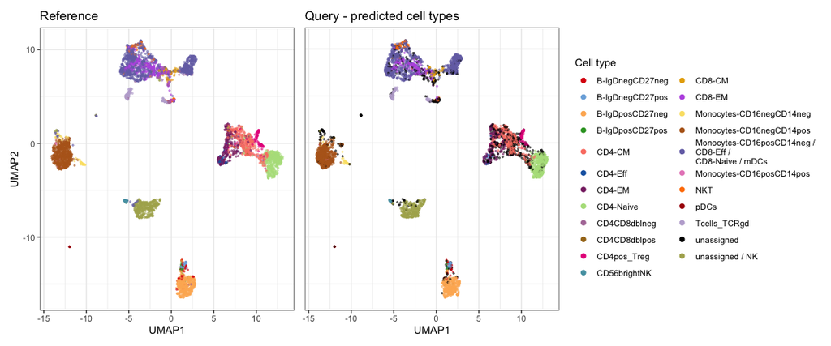

```r
# Define a color per cell type + black for unassigned
celltype_colors <- get_distinct_colors(unique(reference$celltype),
                                       add_unassigned = TRUE)

# UMAP of reference and query
p_umap <- plot_umap(
  reference,
  classified$query,
  markers = markers,
  colors = celltype_colors,
  query_col = "predicted_celltype",
  ref_col = "celltype",
  legend_title = "Cell type",
  add_centroids = FALSE,
  highlight_labels = FALSE,
  sample_n = 5000,
  return_data = TRUE)

p_umap$plot
```

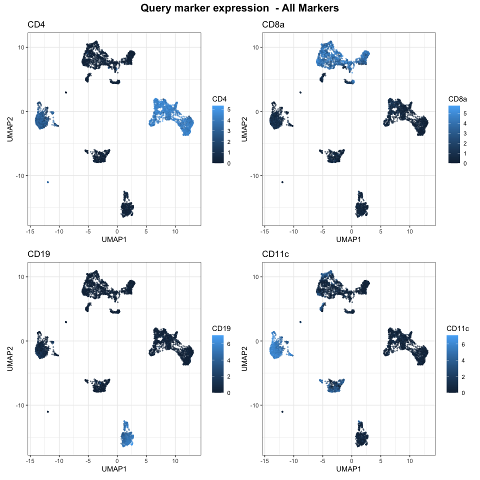

```r
# Plot expression of a set of markers
plot_markers(
  p_umap$query,
  markers = c("CD4", "CD8a", "CD19", "CD11c"),
  title = "Query marker expression",
  ncol = 2)
```

### Celltype abundances

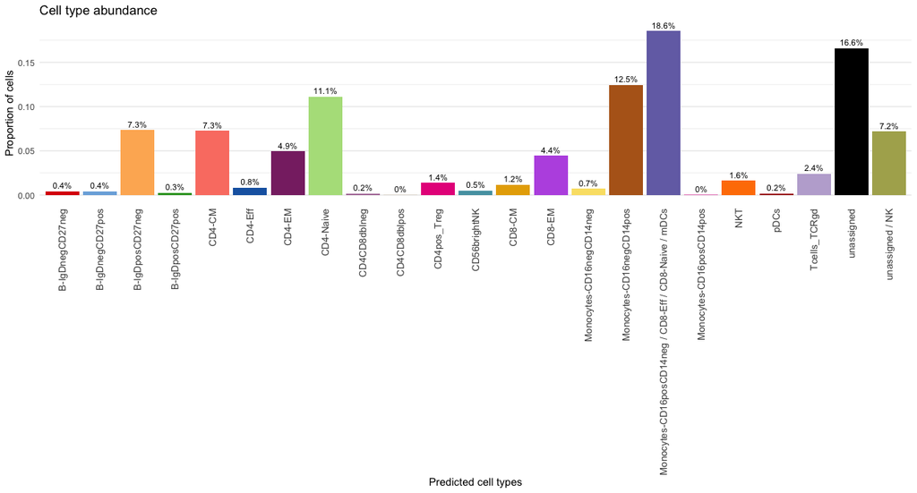

```r
# Barplot of cell type abundances in query
plot_abundance(
  predicted_populations = classified$query$predicted_celltype,
  colors = celltype_colors)
```

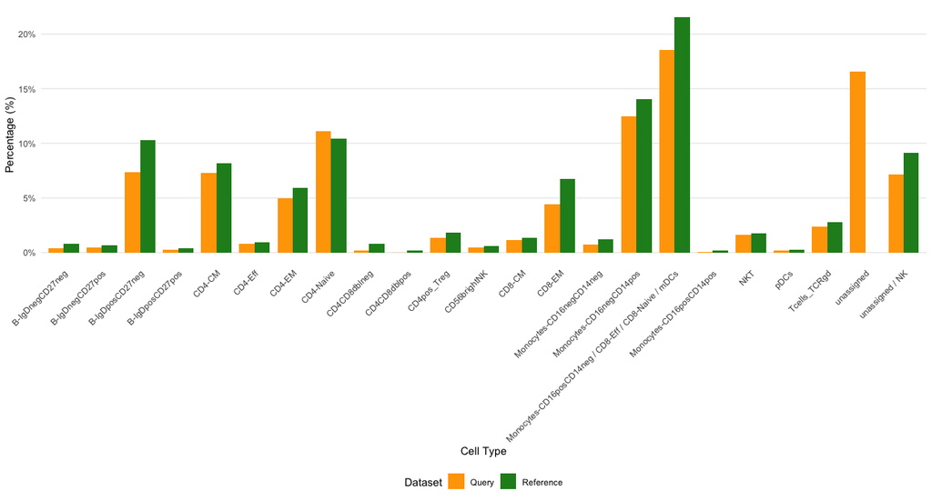

```r
# Compare celltype abundances between query and reference
plot_abundance_comparison(
  reference = reference,
  query = classified$query,
  query_col = "predicted_celltype")
```

### Celltype expression

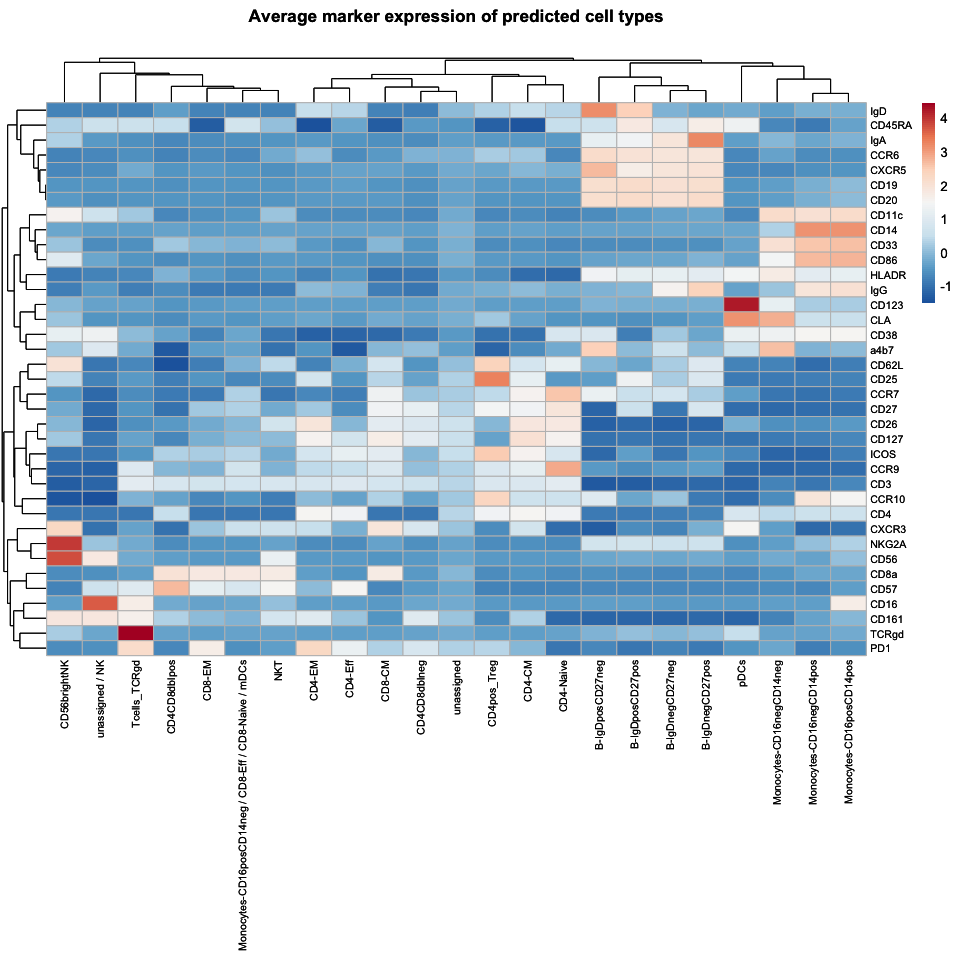

```r
# Heatmap of marker expressions per cell type in query
plot_heatmap(
  classified$query,
  population_col = "predicted_celltype",
  markers_to_plot = markers)
```

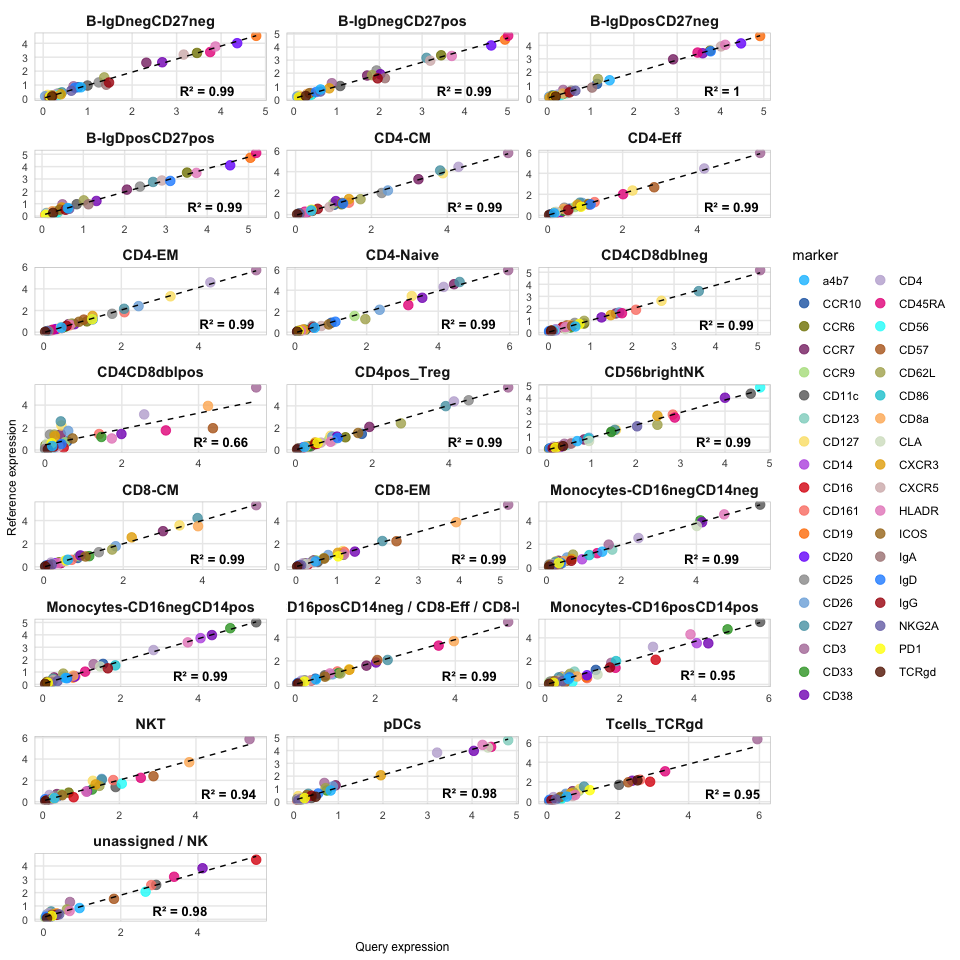

```r
# Celltype-wise expression correlation between reference and query
plot_expression_correlation(
  reference = reference,
  query = classified$query,
  markers = markers,
  query_col = "predicted_celltype")
```

### Alluvium (sankey)

The alluvium plot can illustrate how celltypes are merged or if any missclassifications happen, if compared to true values. Here, we compare before and after unassigned cells are predicted to illustrate how many cells of each type are labeled unassigned.

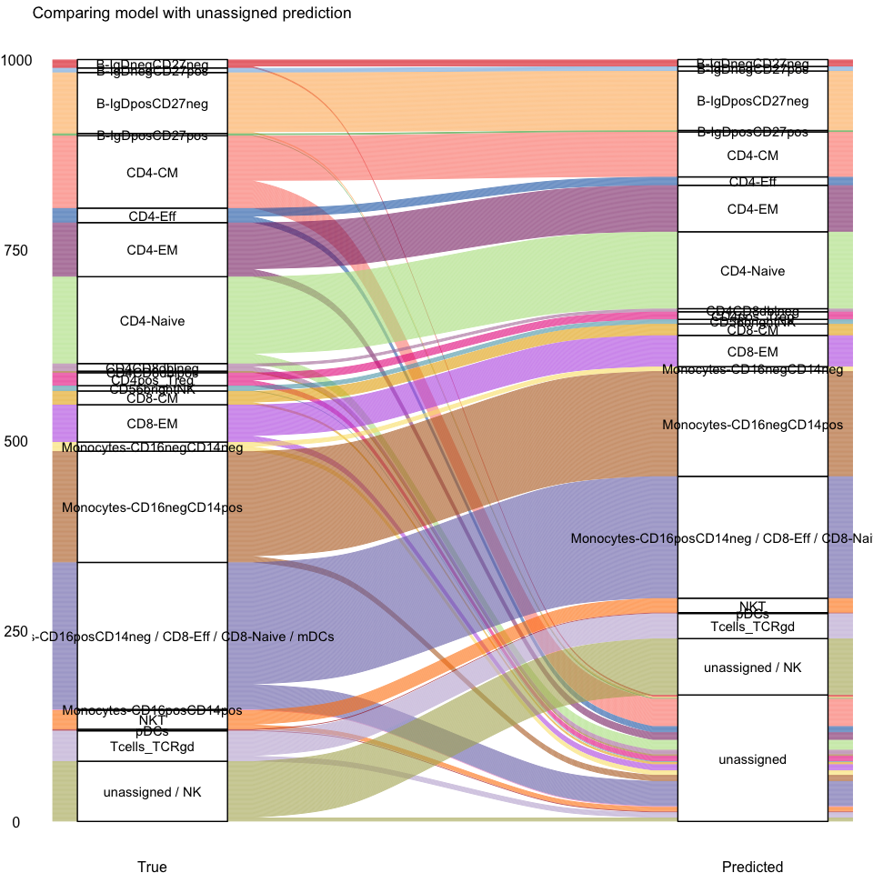

```r
# Alluvium plot of annotation changes - true vs predicted or model_prediction vs predicted_celltype
plot_alluvium(
  classified$query,
  predicted = "predicted_celltype",
  true = "model_prediction",
  color = celltype_colors,
  n = 1000,
  names = c("Model vs predicted"),
  title = "Comparing model with unassigned prediction")
```

### Marker importance

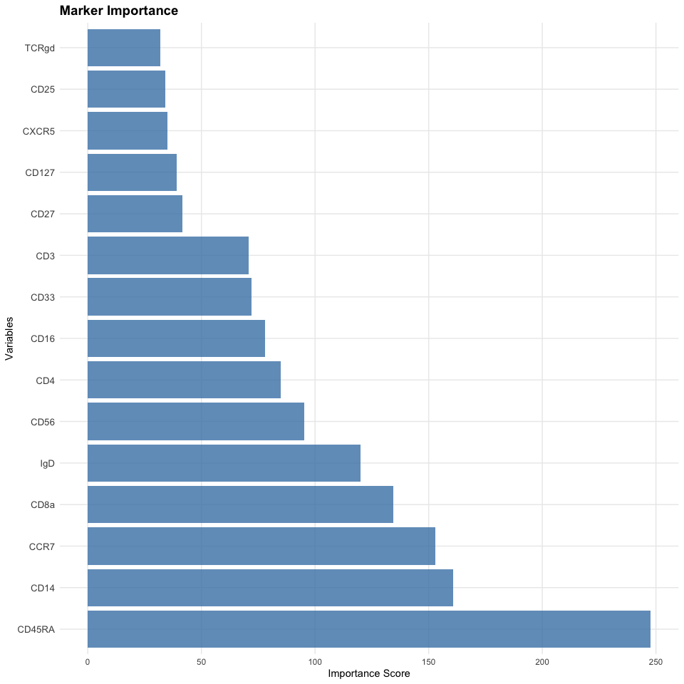

```r
# Importance of each marker in the classification
plot_marker_importance(classified$model, top_n = 15)
```

#### Marker usage

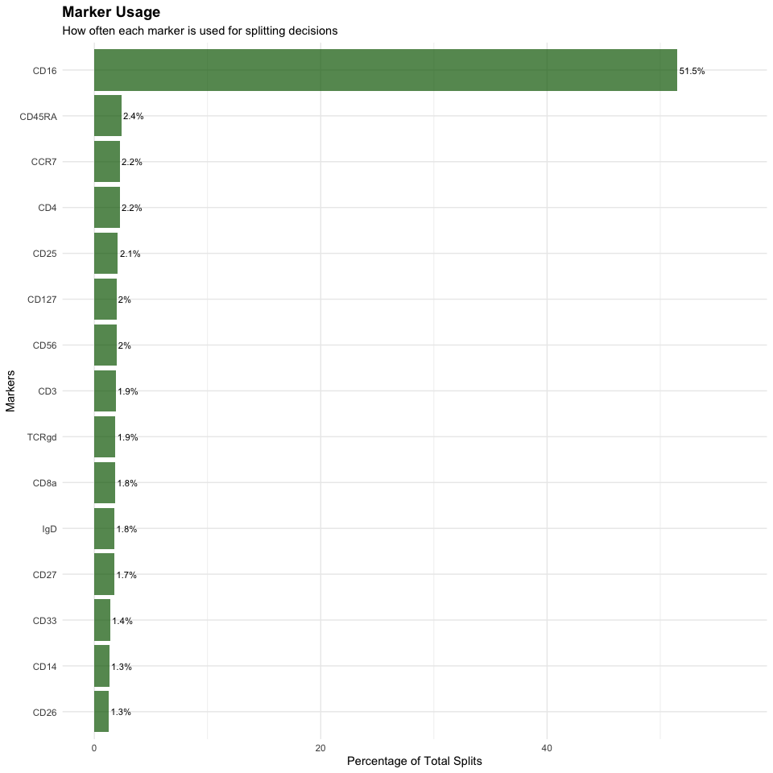

```r
# Importance of each marker in the classification per celltype
plot_marker_usage(classified$model)
```

#### Marker importance per celltype

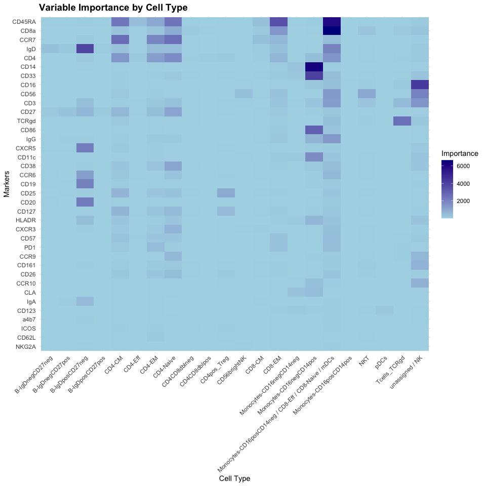

```r
# Importance of each marker in the classification per celltype
plot_marker_importance_cell(reference, markers = markers)
```

#### Top marker importance per celltype

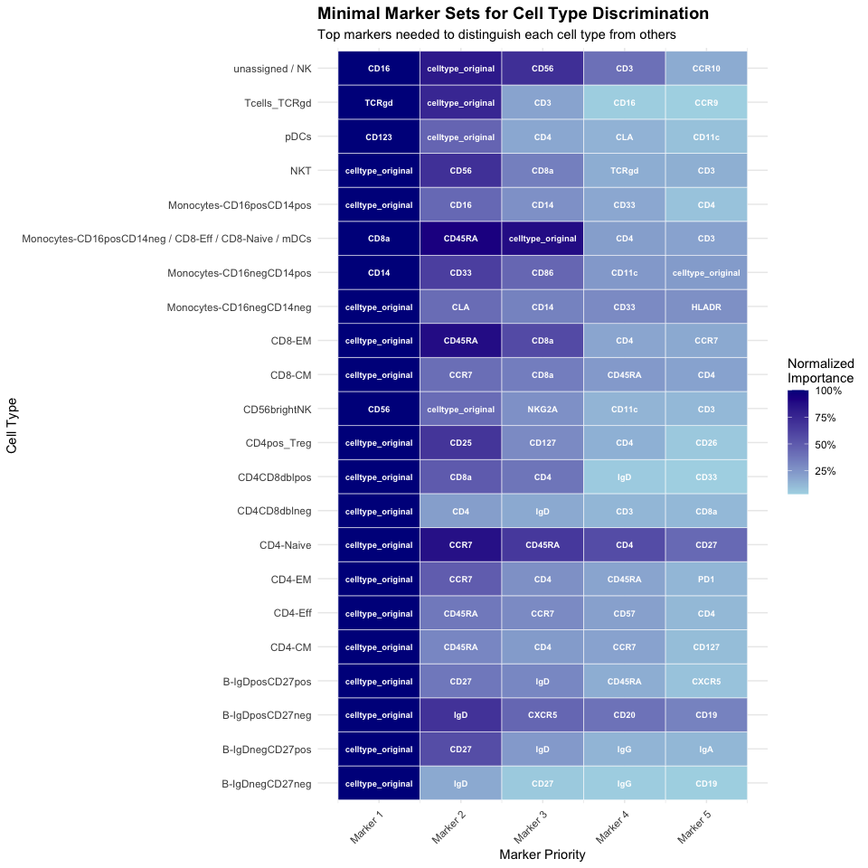

```r
# Importance of each marker in the classification per celltype
plot_top_marker_importance(reference)
```

## Report issues

If you have any issues or questions regarding the use of `cyDefine`, please do not hesitate to raise an issue on GitHub. In this way, others may also benefit from the answers and discussions.